# 3. Summaries

# Interannual plots

Summarized variables can be ploted and statistically tested to reveal interannual changes. The basic function for plotting is `gr_plot_vars()`. Just pass the names of the variables that you want to plot, and the desired plotting layout. Different background fill colors are used to differentiate seasons:

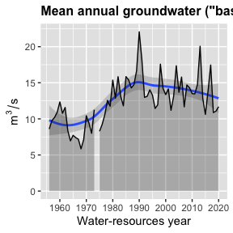

```r
# plot one selected variable
gr_plot_vars(vars, Qygr)
```

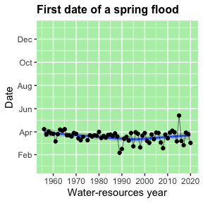

```r
# plot one selected variable
gr_plot_vars(vars, Dspstart)
```

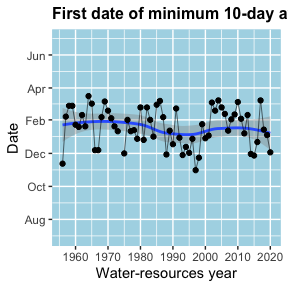

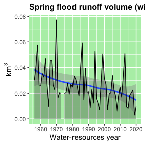

```r
# plot two variables sequentially
gr_plot_vars(vars, D10w1, Wsprngr)
```

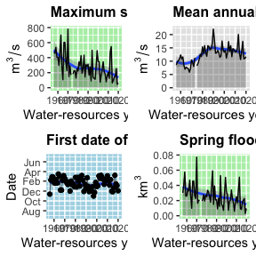

```r
# plot four variables in matrix layout
gr_plot_vars(vars, Qspmax, Qygr, D10w1, Wsprngr,
             layout = matrix(1:4, nrow = 2, byrow = TRUE))
```

Tests can be calculated on the fly during the variable plotting or passed into `tests =` parameters. In this case the plots are supplemented with trend line and change year:

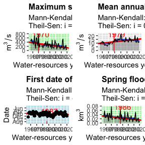

```r
# add tests calculated on the fly (only plotted variables are tested)
gr_plot_vars(vars, Qspmax, Qygr, D10w1, Wsprngr,
             layout = matrix(1:4, nrow = 2, byrow = TRUE),
             tests = TRUE)
```

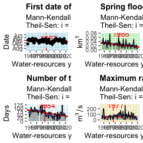

```r
# calculate tests beforehand
tests = gr_test_vars(vars)
gr_plot_vars(vars, D10w1, Wsprngr, Nthw, Qrnmax,
             layout = matrix(1:4, nrow = 2, byrow = TRUE),
             tests = tests)
```

# Period plots

Period plots are boxplots produced by `gr_plot_periods()` for hydrograph separation variables. The data for each variable is divided into two sample periods: before and after the change year either set by `year` parameter or extracted from `tests` (statistically estimated). Different background fill colors are used to differentiate seasons:

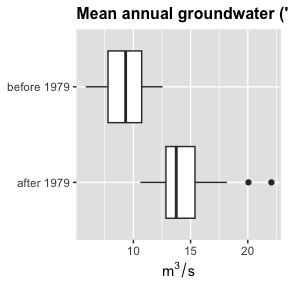

```r
# plot periods with fixed change year
gr_plot_periods(vars, Qygr, year = 1979)
```

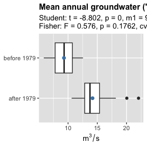

```r
# plot periods with change year from Pettitt test
gr_plot_periods(vars, Qygr, tests = TRUE)
```

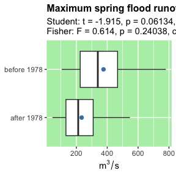

```r
# calculate test beforehand
gr_plot_periods(vars, Qspmax, tests = tests)
```

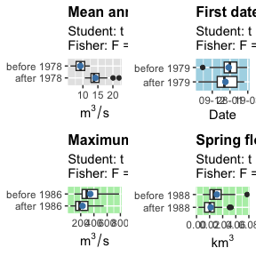

```r
# use matrix layout to plot multiple variables
gr_plot_periods(vars, Qygr, Qspmax, D10w1, Wsprngr,
                layout = matrix(1:4, nrow = 2),
                tests = tests)
```

# Minimum runoff month plots

A histogram of a minimum runoff month for two periods: before and after the change year set by `year` parameter. This kind of plot is produced by `gr_plot_minmonth()`:

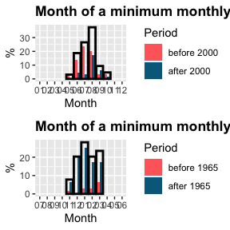

```r
# plot minimum runoff month for two periods divided by Pettitt test
gr_plot_minmonth(vars, tests = gr_test_vars(vars))
```

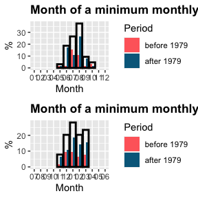

```r
# plot minimum runoff month for two periods divided by fixed year
gr_plot_minmonth(vars, year = 1979)
```

# Test plots

Test plots produced by `gr_plot_tests()` are intended to facilitate the visual analysis of statistical tests. Currently only the change year density is available as a plotting variable:

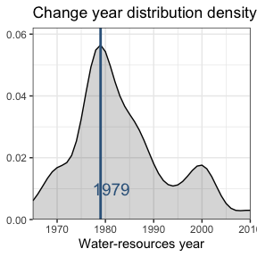

```r
# plot change year from Pettitt test
gr_plot_tests(tests, type = 'year')
```

As can be seen from this plot, most of the variables demonstrate the change in their statistical behavior around $1979$ year.